by [MachinaFantasma](https://phantomachine.github.io/) | [Twitter](https://twitter.com/MachinaFantasma)

# Table of Contents

```python
import numpy as np
import pandas as pd
import matplotlib.pyplot as plt
from IPython.display import YouTubeVideo
```

# Apple, Oranges, Quantities and Inflation

Suppose at each date $t = 0, 1, 2, ..., T-1$, we have data collected

- on prices $p_{i,t}$
- on quantities $q_{it}$ , of individual *products* (i.e., goods and services) $i = 0, 1, ..., N-1$.

How do you compare *expenditure* **quantities** over time ...

... when it does not make sense to compare between expenditures on apples and oranges?

... Or between haircuts and cars?

We could just aggregate up the market-traded *value*

- i.e., calculate prices times quantity of each product variety, then sum up across all varieties.

That's what we call **nominal GDP**.

So then GDP (for $N$ types of goods) at each date $t$, measured using respective date-$\tau$ prices would be:

$$ Y_{t}^{\tau} = p_{0,\tau}q_{0,t} + p_{1,\tau}q_{1,t} + ... + p_{N-1,\tau}q_{N-1,t} \equiv \sum_{i=0}^{N-1}p_{i,\tau}q_{i,t}. $$

- If $\tau = t$, then the measure is a current, date-$t$ nominal GDP: $Y_{t}^{t}$
- If $\tau \neq t$, then we have $Y_{t}^{\tau}$ measured in date-$\tau$ constant prices.

## Problems?

The measure $Y_{t}^{t}$ is confounded by *two sources* of moving parts (that change over time)!

- Individual product prices $p_{it}$ may change (inflation), and/or,
- Individual product quantities $q_{it}$ may change.

So changes in this measure $Y_{t}^{t}$ over time cannot tell us *cleanly* whether they were due to inflationary effects or due to actual variations in the quantities of traded products from year to year!

## Solutions?

- The human brain thinks best in one dimension, using single numbers ...
  - Construct a single *index* which gives us an *aggregated* measure of these quantities.
  - But *index* needs to somehow control for the source of variation due to changes in product prices.
- We could have fixed a $\tau$ and then call $Y_{t}^{\tau}$ real GDP in year-$\tau$ (constant) prices.
  - Two flavors: Laspeyres index and Paasche index.
  - But these two methods suffer from changes in product definitions (i.e., product obsolence or creation) and etc.

A better method is called the *Fisher* or *Chain-weighted* index.

# How is the Fisher Index Constructed?

To calculate the Fisher index (i.e., chain-weighted) method of real GDP, we do the following.

**STEP 1.** For every $t = 0,1,2, ...$:

1. Calculate real GDP based on date $t$ prices (Laspeyres index):
   - using date $t$ prices and date $t$ quantities, $(p_{i,t}, q_{i,t})$ to get $Y_{t}^{t}$
   - using date $t$ prices and date $t+1$ quantities, $(p_{i,t}, q_{i,t+1})$ to get $Y_{t+1}^{t}$
1. Calculate real GDP based on date $t+1$ prices (Paasche index):
   - using date $t+1$ prices and date $t$ quantities, $(p_{i,t+1}, q_{i,t})$ to get $Y_{t}^{t+1}$
   - using date $t+1$ prices and date $t+1$ quantities, $(p_{i,t+1}, q_{i,t+1})$ to get $Y_{t+1}^{t+1}$
     - (This is the same as $Y_{t}^{t}$ one period ahead!)
1. Calculate growth rates for any adjacent periods $t$ and $t+1$, for each method:
   - Laspeyres: $g_{t}^{t} = Y_{t+1}^{t}/Y_{t}^{t}$,
   - Paasche: $g_{t}^{t+1} = Y_{t+1}^{t+1}/Y_{t}^{t+1}$,
2. Then compute their geometric average growth:
   - $g_{C,t} = \sqrt{g_{t}^{t} \times g_{t}^{t+1}}$.

This creates a series of growth rates:

$$ \{ g_{C,t} \}_{t=0}^{T-1} := (g_{C,0}, g_{C,1}, ..., g_{C,T-1}). $$

Let's denote $Q$ as the *chain-weighted (Fisher) Real GDP index*.

**STEP 2.** Pick an arbitrary date $\tau$ as the base year, so then the "chain" is relative to this base year.

1. Set $Q_{\tau} = Y_{\tau}^{\tau}$.
2. For each $t < \tau$, compute

\begin{equation} Q_{t} = \frac{Q_{t+1}}{g_{C,t}} \label{eq: CWI forward} \end{equation}

1. For each $t \geq \tau$, compute

\begin{equation} Q_{t+1} = Q_{t} \times g_{C,t} \label{eq: CWI backward} \end{equation}

# Let's dance!

Let's make up some synthetic numbers for prices and quantities.

Below I design a re-usable function called `generate_data_ApplesOranges` to generate an example dataset for prices and quantities of apples and oranges:

```python
def generate_data_ApplesOranges(exp_scale_P_apple=5.99,
                                   exp_scale_P_orange=2.99,
                                   int_min_Q_apple = 1,
                                   int_max_Q_apple = 1000,
                                   int_min_Q_orange = 1,
                                   int_max_Q_orange = 1000,
                                   seed = 244826,
                                   T=3):
    """This function generates random prices (assuming
    they are exponentially distributed) and quantities (assuming
    these are uniformly distributed positive integers). The inputs are
    parameters for the exponential (exp) and uniform integer (int)
    distributions. See NumPy's RANDOM library for details. A default
    random number generator seed is given. The default length of the data
    is T = 3. All these input defaults can be overidden by the user.
    Output is stored in a dictionary (dict) format."""
    # Fix random number generator seed, get same draw each time
    np.random.seed(seed)
    # Assume sample prices drawn from an exponential distribution
    P_apple  = np.random.exponential(scale=exp_scale_P_apple,
                                     size=T)
    P_orange = np.random.exponential(scale=exp_scale_P_orange,
                                     size=T)
    # Assume quantities are drawn from uniform distribution
    # over (positive) integers
    Q_apple = np.random.randint(int_min_Q_apple,
                                high=int_max_Q_apple,
                                size=T)
    Q_orange = np.random.randint(int_min_Q_orange,
                                 high=int_max_Q_orange,
                                 size=T)
    # Store synthetic data in a Python dictionary (dict)
    data = { "P_apple"  : P_apple,
             "P_orange" : P_orange,
             "Q_apple"  : Q_apple,
             "Q_orange" : Q_orange, }
    return data
```

We then call the function `generate_data_ApplesOranges` to produce our synthetic dataset.

```python
# Generate the fake data (dict)
data = generate_data_ApplesOranges()
```

Next, we convert the output `data` into a `Pandas` dataframe ordering the data series by `columns`:

```python
# Convert data (dict) to Pandas dataframe
df = pd.DataFrame.from_dict(data, orient='columns')
```

Take a quick peek at the current dataframe:

```python
df
```

|  | P_apple | P_orange | Q_apple | Q_orange |
| --- | --- | --- | --- | --- |
| 0 | 2.075434 | 1.001738 | 641 | 598 |
| 1 | 0.966716 | 6.069813 | 317 | 39 |
| 2 | 0.945014 | 3.779660 | 638 | 827 |

## Implementing Step 1

Construct nominal GDP for our two-fruit economy: $Y_{t}^{t} = \sum_{i=0}^{N-1}p_{i,t}q_{i,t}$.

```python
# Nominal GDP
Y = df["P_apple"]*df["Q_apple"] + df["P_orange"]*df["Q_orange"]
# Insert as new column to df
df["Y"] = Y
```

Take a quick peek at the updated dataframe.

You should have a new column added with dataframe key called `Y`:

```python
# Let's have a peek-a-boo!
df
```

|  | P_apple | P_orange | Q_apple | Q_orange | Y |
| --- | --- | --- | --- | --- | --- |
| 0 | 2.075434 | 1.001738 | 641 | 598 | 1929.392605 |
| 1 | 0.966716 | 6.069813 | 317 | 39 | 543.171743 |
| 2 | 0.945014 | 3.779660 | 638 | 827 | 3728.697766 |

Construct lagged nominal GDP for out two-fruit economy: $Y_{t-1}^{t-1} = \sum_{i=0}^{N-1}p_{i,t-1}q_{i,t-1}$.

```python
df["Y_lag"] = Y.shift()
```

Take one more quick peek at the updated dataframe.

You should have another new column added with dataframe key called `Y_lag`.

- This is just the data from the `Y` (nominal GDP) series lagged by one period.
- We did this using the `shift()` attribute that is in-built to a `Pandas` dataframe to lag a data series by one period.

Build Laspeyres and Paasche real-GDP indices:

for each $t = 0,1,...,T-1$.

```python
Y_laspeyres = df["P_apple"].shift()*df["Q_apple"] + df["P_orange"].shift()*df["Q_orange"]
Y_paasche = df["P_apple"]*df["Q_apple"].shift() + df["P_orange"]*df["Q_orange"].shift()
```

Update our dataframe ...

```python
df["Y_laspeyres"] = Y_laspeyres
df["Y_paasche"] = Y_paasche
```

Take one more quick peek at the updated dataframe.

You should have new columns added with dataframe key called `Y_laspeyres` and `Y_paasche`:

```python
df
```

|  | P_apple | P_orange | Q_apple | Q_orange | Y | Y_lag | Y_laspeyres | Y_paasche |
| --- | --- | --- | --- | --- | --- | --- | --- | --- |
| 0 | 2.075434 | 1.001738 | 641 | 598 | 1929.392605 | NaN | NaN | NaN |
| 1 | 0.966716 | 6.069813 | 317 | 39 | 543.171743 | 1929.392605 | 696.980307 | 4249.413332 |
| 2 | 0.945014 | 3.779660 | 638 | 827 | 3728.697766 | 543.171743 | 5636.500393 | 446.976279 |

Calculate the growth factor (i.e., one plus the growth rate) for each of the Laspeyres and Paasche indices:

- Laspeyres: $g_{t}^{t} = Y_{t+1}^{t}/Y_{t}^{t}$,
- Paasche: $g_{t}^{t+1} = Y_{t+1}^{t+1}/Y_{t}^{t+1}$,

```python
g_laspeyres = Y_laspeyres/Y.shift()
df["g_laspeyres"]  = g_laspeyres
g_paasche = Y/Y_paasche
df["g_paasche"]  = g_paasche
```

Now we compute the geometric average of these two growth rates as:

$g_{C,t} = \sqrt{g_{t}^{t} \times g_{t}^{t+1}}$

Then we update the dataframe `df`.

```python
g_C = np.sqrt(g_laspeyres*g_paasche)
df["g_C"] = g_C
```

```python
df
```

|  | P_apple | P_orange | Q_apple | Q_orange | Y | Y_lag | Y_laspeyres | Y_paasche | g_laspeyres | g_paasche | g_C |
| --- | --- | --- | --- | --- | --- | --- | --- | --- | --- | --- | --- |
| 0 | 2.075434 | 1.001738 | 641 | 598 | 1929.392605 | NaN | NaN | NaN | NaN | NaN | NaN |
| 1 | 0.966716 | 6.069813 | 317 | 39 | 543.171743 | 1929.392605 | 696.980307 | 4249.413332 | 0.361243 | 0.127823 | 0.214884 |
| 2 | 0.945014 | 3.779660 | 638 | 827 | 3728.697766 | 543.171743 | 5636.500393 | 446.976279 | 10.377013 | 8.342048 | 9.304061 |

**Notes**

Did you notice that $g_{C,t}$ is always a number between the two growth rates $g_{t}^{t}$ (i.e., `g_laspeyres`) and $g_{t}^{t+1}$ (i.e., `g_paasche`), at each date $t$?

This is a result from the geometric average definition.

## Implementing Step 2

Pick an arbitrary date $\tau$ as the base year, so then the "chain" is relative to this base year.

- Set $Q_{\tau} = Y_{\tau}^{\tau}$.
- For each $t < \tau$, compute

\begin{equation} Q_{t} = \frac{Q_{t+1}}{g_{C,t}} \tag{\ref{eq: CWI forward}} \end{equation}

- For each $t \geq \tau$, compute

\begin{equation} Q_{t+1} = Q_{t} \times g_{C,t} \tag{\ref{eq: CWI backward}} \end{equation}

```python
# Determine length of data series
T = df.index.size

# Pre-allocate memory for Q series of length T
Q = np.empty(T)

# base date τ implies  Q(τ) = Y(τ)
τ = 1
Q[τ] = df["Y"][τ]

# Do the chain-weighted index forward, and backward
# relative to base year τ:

# Formula (2) for t >= τ (iterate forward)
for t in range(τ, T-1, 1):
    gC_t = df["g_C"][t+1]
    Q[t+1] = Q[t]*gC_t

# Formula (1) for t < τ (iterate backward)
for t in range(τ, 0, -1):
    Q[t-1] = Q[t]/df["g_C"][t]
```

```python
df["Q"] = Q
df
```

|  | P_apple | P_orange | Q_apple | Q_orange | Y | Y_lag | Y_laspeyres | Y_paasche | g_laspeyres | g_paasche | g_C | Q |
| --- | --- | --- | --- | --- | --- | --- | --- | --- | --- | --- | --- | --- |
| 0 | 2.075434 | 1.001738 | 641 | 598 | 1929.392605 | NaN | NaN | NaN | NaN | NaN | NaN | 2527.744206 |
| 1 | 0.966716 | 6.069813 | 317 | 39 | 543.171743 | 1929.392605 | 696.980307 | 4249.413332 | 0.361243 | 0.127823 | 0.214884 | 543.171743 |
| 2 | 0.945014 | 3.779660 | 638 | 827 | 3728.697766 | 543.171743 | 5636.500393 | 446.976279 | 10.377013 | 8.342048 | 9.304061 | 5053.702921 |

Let's plot our data series:

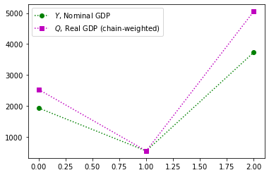

```python
plt.figure()
plt.plot(df.index, df["Y"], ":og", label=r"$Y$, Nominal GDP")
plt.plot(df.index, df["Q"], ":sm", label=r"$Q$, Real GDP (chain-weighted)")
plt.legend()
plt.show()
```

**Notes.**

While the real, chain-weighted series $Q$ seems to follow the pattern of the nominal series $Y$, the nominal series' movement is complicated by both changes in underlying products' prices and quantities at the same.

The real series $Q$ instead, "controls" for price change effects. Hence the qualifier *real*.

Since we set $\tau = 1$ as the base year, both $Y$ and $Q$ should agree, or intersect, at the same point at time $t = \tau$. This is by definition of the Fisher or chain-weighted index formula.

# Homework (exam-style)

1. Make up your own numbers for prices and quantities at each date $t$ and product $i$.
2. Repeat the task in the last part for your example.

# Answer to Homework

```python
YouTubeVideo('VbD_kBJc_gI')
```

[video not shown]

In the demo earlier, we worked with an example of $N=2$ products (apples and oranges).

In reality we have possibly millions of product categories in a database making up the components of GDP!

Clearly the code we wrote above would not be general enough to deal with this!

Below, we revamp our code and make use of some array multiplication tricks from `NumPy` to represent sums like $\sum_{i=0}^{N-1}p_{i}q_{i}$ where $N$ is a very large integer.

For illustration, we just look at the case of $N=3$.

```python
def generate_data( p_labels = ["p_0", "p_1", "p_2"],
                   q_labels = ["q_0", "q_1", "q_2"],
                   exp_scale_P = [5.99, 3.23, 7.69],
                   int_min_Q = [1, 3, 8],
                   int_max_Q = [1000, 700, 2000],
                   seed = 244826,
                   T=50):
    """This function generates random prices (assuming
    they are exponentially distributed) and quantities (assuming
    these are uniformly distributed positive integers). The inputs are
    parameters (list) for the exponential (exp) and uniform integer (int)
    distributions. See NumPy's RANDOM library for details. A default
    random number generator seed is given. The default length of the data
    is T = 3. All these input defaults can be overidden by the user.
    Output is stored in a dictionary (dict) format."""

    # Number of products
    N = len(p_labels)

    # Fix random number generator seed, get same draw each time
    np.random.seed(seed)

    # Concatenate labels
    data_labels = p_labels + q_labels

    # Initial DATA dict, loop of product indexes i=0,..., N-1
    p = {}
    q = {}
    for i in range(N):
        # Current product is i: p ~ exponential
        expscale = exp_scale_P[i]
        p_i = np.random.exponential(scale=expscale, size=T)
        # Engineer a linear time trend
        p_i = p_i + np.arange(T)
        # Current product is i: q ~ random integer > 0
        int_min = int_min_Q[i]
        int_max = int_max_Q[i]
        q_i = np.random.randint(int_min, high=int_max, size=T)
        q_i = q_i + np.arange(T)
        # Update dictionary
        p[p_labels[i]] = p_i
        q[q_labels[i]] = q_i
    return p, q, p_labels, q_labels
```

Let's invoke an instance specified in the default inputs for `generate_data`:

```python
p, q, p_labels, q_labels = generate_data()
```

We've designed `generate_data` such that the output `p` and `q` are dictionaries.

Let's merge these two together (for importing to `Pandas`):

```python
# Make copy (so p is unchanged) to ...
data3 = p.copy()

# Merge/update with dict q ...
data3.update(q)
```

```python
# Convert data (dict) to Pandas dataframe
df3 = pd.DataFrame.from_dict(data3, orient='columns')

# Take a peek ...
df3.head()
```

|  | p_0 | p_1 | p_2 | q_0 | q_1 | q_2 |
| --- | --- | --- | --- | --- | --- | --- |
| 0 | 2.075434 | 2.293168 | 0.723387 | 828 | 203 | 735 |
| 1 | 1.966716 | 1.896899 | 7.139682 | 938 | 603 | 640 |
| 2 | 2.945014 | 2.033992 | 58.176429 | 904 | 645 | 1694 |
| 3 | 5.006827 | 3.390576 | 7.546911 | 429 | 214 | 348 |
| 4 | 16.159927 | 7.693805 | 4.912581 | 672 | 98 | 833 |

```python
# Tail view ...
df3.tail()
```

|  | p_0 | p_1 | p_2 | q_0 | q_1 | q_2 |
| --- | --- | --- | --- | --- | --- | --- |
| 45 | 46.419667 | 46.022883 | 48.045281 | 63 | 739 | 749 |
| 46 | 62.043660 | 48.759694 | 46.659856 | 130 | 246 | 730 |
| 47 | 48.061522 | 48.933959 | 52.152081 | 484 | 133 | 1565 |
| 48 | 58.526752 | 56.857947 | 49.971925 | 877 | 173 | 1791 |
| 49 | 53.408002 | 55.878413 | 76.914254 | 394 | 541 | 703 |

## Implementing Step 1

Let's extract a subset of the dataframe as separate dataframes of prices series `p`, and, quantities series `q`:

```python
p = df3[["p_0", "p_1", "p_2"]]
q = df3[["q_0", "q_1", "q_2"]]
```

That way I can do the following in one line of code:

1. Calculate element-wise multiplication of prices and quantities for each product category $i = 0, 1, ..., N-1$; and
2. sum across the columns to get nominal GDP for each date $t = 0,..., T-1$.

```python
# Current date nominal GDP
Y = np.multiply(p,q).sum(axis=1)

# Store nominal GDP into dataframe
df3["Y"] = Y
```

```python
# Quick view of first few rows of dataframe
df3.head()
```

|  | p_0 | p_1 | p_2 | q_0 | q_1 | q_2 | Y |
| --- | --- | --- | --- | --- | --- | --- | --- |
| 0 | 2.075434 | 2.293168 | 0.723387 | 828 | 203 | 735 | 2715.661998 |
| 1 | 1.966716 | 1.896899 | 7.139682 | 938 | 603 | 640 | 7558.005922 |
| 2 | 2.945014 | 2.033992 | 58.176429 | 904 | 645 | 1694 | 102525.087557 |
| 3 | 5.006827 | 3.390576 | 7.546911 | 429 | 214 | 348 | 5499.836965 |
| 4 | 16.159927 | 7.693805 | 4.912581 | 672 | 98 | 833 | 15705.643379 |

Likewise, I can lag the prices series by one period and calculate the Laspeyres index:

```python
# Laspeyres method of real GDP index
Y_las = np.multiply(p.shift(),q).sum(axis=1)
df3["Y_laspeyres"] = Y_las
```

Similarly for the Paasche index:

```python
# Paasche method of real GDP index
Y_pas = np.multiply(p,q.shift()).sum(axis=1)
df3["Y_paasche"] = Y_pas
```

```python
# Quick view of first few rows of dataframe
df3.head()
```

|  | p_0 | p_1 | p_2 | q_0 | q_1 | q_2 | Y | Y_laspeyres | Y_paasche |
| --- | --- | --- | --- | --- | --- | --- | --- | --- | --- |
| 0 | 2.075434 | 2.293168 | 0.723387 | 828 | 203 | 735 | 2715.661998 | 0.000000 | 0.000000 |
| 1 | 1.966716 | 1.896899 | 7.139682 | 938 | 603 | 640 | 7558.005922 | 3792.504982 | 7261.177369 |
| 2 | 2.945014 | 2.033992 | 58.176429 | 904 | 645 | 1694 | 102525.087557 | 15096.031638 | 41221.834662 |
| 3 | 5.006827 | 3.390576 | 7.546911 | 429 | 214 | 348 | 5499.836965 | 21944.082497 | 19497.559769 |
| 4 | 16.159927 | 7.693805 | 4.912581 | 672 | 98 | 833 | 15705.643379 | 9983.440774 | 10288.660843 |

We then compute the Fisher geometric average growth factor from the growth factors associated with the Laspeyres and Paasche methods:

```python
g_las = Y_las/Y.shift()
df3["g_las"]  = g_las
g_pas = Y/Y_pas
df3["g_paasche"]  = g_pas
g_fish = np.sqrt(g_las*g_pas)
df3["g_fisher"] = g_fish
```

```python
# Quick view of first few rows of dataframe
df3.head()
```

|  | p_0 | p_1 | p_2 | q_0 | q_1 | q_2 | Y | Y_laspeyres | Y_paasche | g_las | g_paasche | g_fisher |
| --- | --- | --- | --- | --- | --- | --- | --- | --- | --- | --- | --- | --- |
| 0 | 2.075434 | 2.293168 | 0.723387 | 828 | 203 | 735 | 2715.661998 | 0.000000 | 0.000000 | NaN | inf | NaN |
| 1 | 1.966716 | 1.896899 | 7.139682 | 938 | 603 | 640 | 7558.005922 | 3792.504982 | 7261.177369 | 1.396531 | 1.040879 | 1.205661 |
| 2 | 2.945014 | 2.033992 | 58.176429 | 904 | 645 | 1694 | 102525.087557 | 15096.031638 | 41221.834662 | 1.997356 | 2.487155 | 2.228842 |
| 3 | 5.006827 | 3.390576 | 7.546911 | 429 | 214 | 348 | 5499.836965 | 21944.082497 | 19497.559769 | 0.214036 | 0.282078 | 0.245713 |
| 4 | 16.159927 | 7.693805 | 4.912581 | 672 | 98 | 833 | 15705.643379 | 9983.440774 | 10288.660843 | 1.815225 | 1.526500 | 1.664614 |

## Implementing Step 2

Like in the simple example earlier, we can now compute the Fisher index of real GDP in this bigger example.

The code below repeats the one from above, except for a different dataframe name!

We choose date $\tau$ to be the base year.

```python
# Determine length of data series
T = df3.index.size

# Pre-allocate memory for Q series of length T
Q = np.empty(T)

# base date τ implies  Q(τ) = Y(τ)
τ = 21
Q[τ] = df3["Y"][τ]

# Do the chain-weighted index forward, and backward
# relative to base year τ:

# Formula (2) for t >= τ (iterate forward)
for t in range(τ, T-1, 1):
    gC_t = df3["g_fisher"][t+1]
    Q[t+1] = Q[t]*gC_t

# Formula (1) for t < τ (iterate backward)
for t in range(τ, 0, -1):
    gC_t = df3["g_fisher"][t]
    Q[t-1] = Q[t]/gC_t
```

```python
df3["Q"] = Q
df3.head()
```

|  | p_0 | p_1 | p_2 | q_0 | q_1 | q_2 | Y | Y_laspeyres | Y_paasche | g_las | g_paasche | g_fisher | Q |
| --- | --- | --- | --- | --- | --- | --- | --- | --- | --- | --- | --- | --- | --- |
| 0 | 2.075434 | 2.293168 | 0.723387 | 828 | 203 | 735 | 2715.661998 | 0.000000 | 0.000000 | NaN | inf | NaN | 40363.568400 |
| 1 | 1.966716 | 1.896899 | 7.139682 | 938 | 603 | 640 | 7558.005922 | 3792.504982 | 7261.177369 | 1.396531 | 1.040879 | 1.205661 | 48664.791550 |
| 2 | 2.945014 | 2.033992 | 58.176429 | 904 | 645 | 1694 | 102525.087557 | 15096.031638 | 41221.834662 | 1.997356 | 2.487155 | 2.228842 | 108466.110778 |
| 3 | 5.006827 | 3.390576 | 7.546911 | 429 | 214 | 348 | 5499.836965 | 21944.082497 | 19497.559769 | 0.214036 | 0.282078 | 0.245713 | 26651.550811 |
| 4 | 16.159927 | 7.693805 | 4.912581 | 672 | 98 | 833 | 15705.643379 | 9983.440774 | 10288.660843 | 1.815225 | 1.526500 | 1.664614 | 44364.556096 |

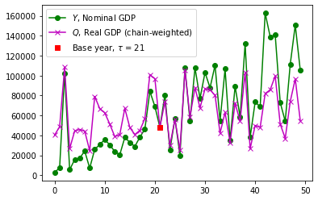

```python
plt.figure()
plt.plot(df3.index, df3["Y"], "-og", label=r"$Y$, Nominal GDP")
plt.plot(df3.index, df3["Q"], "-xm", label=r"$Q$, Real GDP (chain-weighted)")
plt.plot(τ, df3["Q"][τ], 'sr', label="Base year, "+ r"$\tau$ = " + str(τ))
plt.legend()
plt.show()
```

So there we have it, a hands on experience on rolling your own version of Irving Fisher's famous 1922 method of calculating chain weighted indices.

Why don't you test drive the methods above on some real-world data on prices and quantities for your country's national account of interest?

# Reference

- Whelan, K. (2002), A Guide To U.S. Chain Aggregated NIPA Data. *Review of Income and Wealth*, 48: 217-233. [doi:10.1111/1475-4991.00049](https://doi.org/10.1111/1475-4991.00049)
- Fisher, I. (1922), [*The Making of Index Numbers: A Study of Their Varieties, Tests, and Reliability*](https://books.google.com.au/books/about/The_Making_of_Index_Numbers.html?id=amAMCByD-JkC&source=kp_book_description&redir_esc=y).